# Network Travel in Aarhus

# 4. Construct a routable street network

In this step, we convert the street centerlines into a routable network structure. This basically means that we make it explicit which street segments share an endpoint, such that we know how streets are connected, and hence, how someone can travel from A to B. This can be done very easily with the sfnetworks package. Note that for now we simply assume each street can be traveled in both directions, and the network is therefore undirected.

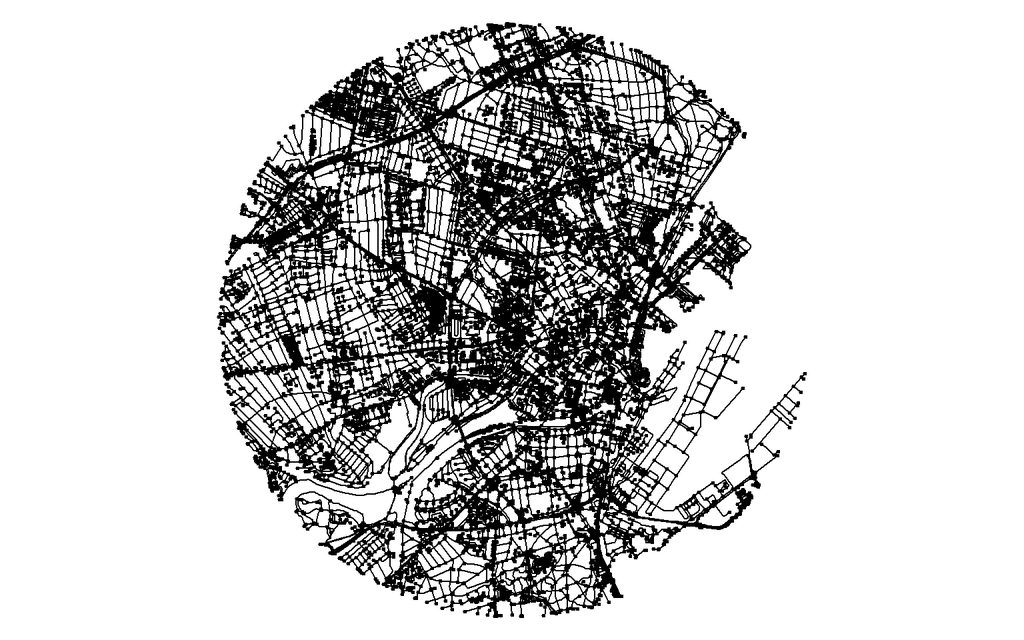

```r
network <- sfnetworks::as_sfnetwork(streets, directed = FALSE)

par(mar = c(0, 0, 0, 0))
plot(network, cex = 0.5)
```

However, streets in OpenStreetMap are not always mapped with a network structure in mind. It happens often that connected street segments cross each other without sharing an endpoint. This results in many disconnected sets of streets in the network, as shown below. Even our small network has over 5000 disconnected components, with the largest of them containing around 20% of all nodes.

```r
tidygraph::with_graph(network, tidygraph::graph_component_count())
```

```
[1] 5432
```

```r
node_count_all <- network %>%
    tidygraph::with_graph(tidygraph::graph_order())

node_count_largest <- network %>%
    tidygraph::convert(tidygraph::to_largest_component) %>%
    tidygraph::with_graph(tidygraph::graph_order())

round(node_count_largest/node_count_all * 100)
```

```
[1] 20
```

Luckily, the sfnetworks package contains functions to pre-process and clean networks. One of them is `to_spatial_subdivision()`, which connects streets when they share internal vertices rather than only endpoints. This results in a network that still has some disconnected components (which is to be expected since we cut the network at the buffer boundaries), but with the largest of them containing almost all nodes.

Tip There are many more network pre-processing and cleaning functions in sfnetworks. See the `sfnetworks documentation` for details.

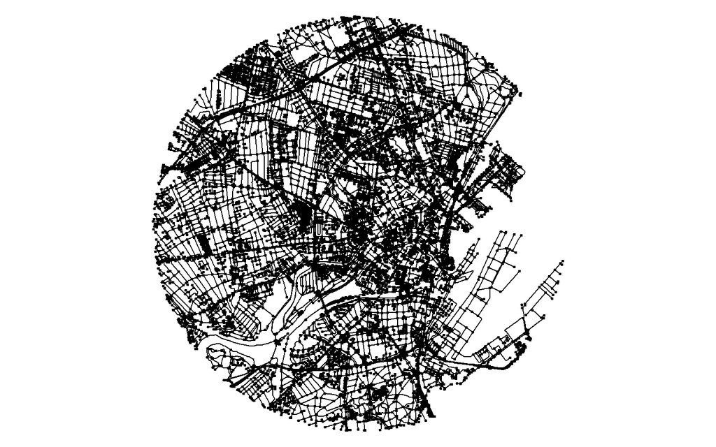

```r
network <- network %>%
    tidygraph::convert(sfnetworks::to_spatial_subdivision)

par(mar = c(0, 0, 0, 0))
plot(network, cex = 0.5)
```

```r
tidygraph::with_graph(network, tidygraph::graph_component_count())
```

```
[1] 181
```

```r
node_count_all <- network %>%
    tidygraph::with_graph(tidygraph::graph_order())

node_count_largest <- network %>%
    tidygraph::convert(tidygraph::to_largest_component) %>%
    tidygraph::with_graph(tidygraph::graph_order())

round(node_count_largest/node_count_all * 100)
```

```
[1] 98
```

Now we can select the largest component without having to worry we loose a lot of data.

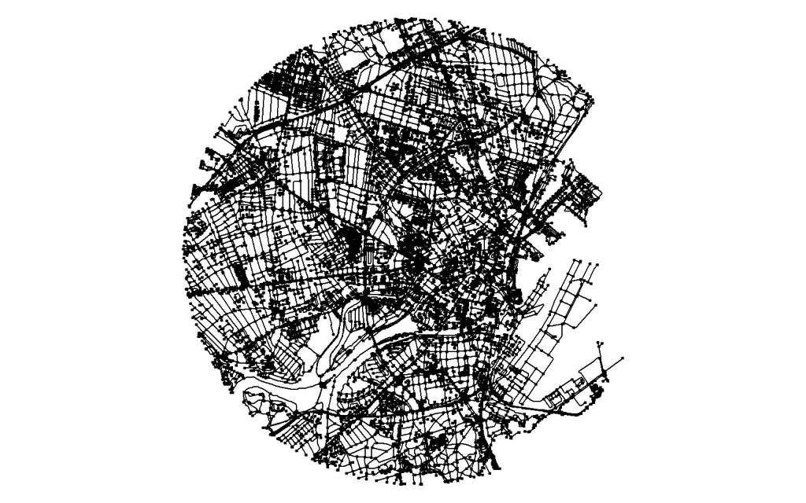

```r
network <- network %>%
    tidygraph::convert(tidygraph::to_largest_component)

par(mar = c(0, 0, 0, 0))
plot(network, cex = 0.5)
```

# 5. Compute accessibility to shelters

Let’s check if data is ready for time calculation:

```r
# Are all geometries valid?
any(!st_is_valid(network))
```

```
[1] FALSE
```

```r
# Inspect the network for NaN values in the 'time' weights
any(is.na(network %>%
    activate("edges") %>%
    pull(time)))
```

```
[1] TRUE
```

```r
# List edges with NaN time values
network %>%
    activate("edges") %>%
    filter(is.na(time)) %>%
    as_tibble()
```

```
Simple feature collection with 898 features and 255 fields
Geometry type: LINESTRING
Dimension:     XY
Bounding box:  xmin: 10.17415 ymin: 56.13156 xmax: 10.21788 ymax: 56.18604
Geodetic CRS:  WGS 84
# A tibble: 898 × 256
    from    to osm_id   name          access `access:conditional` `access:lanes`
   <int> <int> <chr>    <chr>         <chr>  <chr>                <chr>
 1   444   445 13512432 <NA>          <NA>   <NA>                 <NA>
 2   721   722 20037850 Kornbakke Al… <NA>   <NA>                 <NA>
 3   722   723 20037850 Kornbakke Al… <NA>   <NA>                 <NA>
 4   723   724 20037850 Kornbakke Al… <NA>   <NA>                 <NA>
 5   724   725 20037850 Kornbakke Al… <NA>   <NA>                 <NA>
 6   725   726 20037850 Kornbakke Al… <NA>   <NA>                 <NA>
 7   726   727 20037850 Kornbakke Al… <NA>   <NA>                 <NA>
 8   727   728 20037850 Kornbakke Al… <NA>   <NA>                 <NA>
 9   728   729 20037850 Kornbakke Al… <NA>   <NA>                 <NA>
10   729   730 20037850 Kornbakke Al… <NA>   <NA>                 <NA>
# ℹ 888 more rows
# ℹ 249 more variables: `access:lanes:backward` <chr>, alt_name <chr>,
#   amenity <chr>, area <chr>, artist_name <chr>, artwork_type <chr>,
#   barrier <chr>, bench <chr>, bicycle <chr>, `bicycle:backward` <chr>,
#   `bicycle:forward` <chr>, `bicycle:lanes` <chr>, bin <chr>, bridge <chr>,
#   building <chr>, `building:colour` <chr>, `building:levels` <chr>,
#   `building:levels:underground` <chr>, `building:material` <chr>, …
```

```r
# Filter out invalid edges (e.g., NaN values in the 'time' attribute)
valid_network <- network %>%
    activate("edges") %>%
    filter(!is.na(time))  # Keep only edges where time is not NaN
```

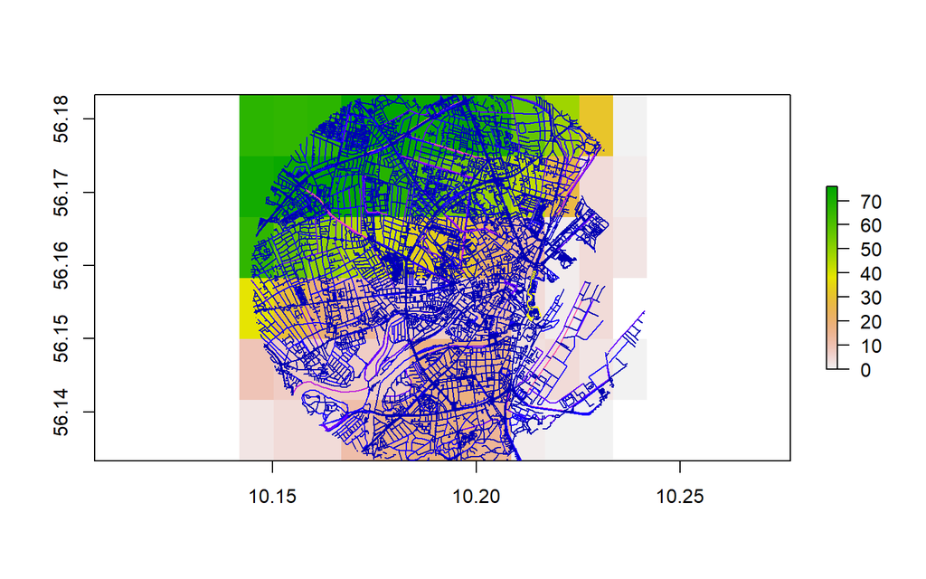

```r
plot(dem)
plot(streets["time"], add = TRUE)
```

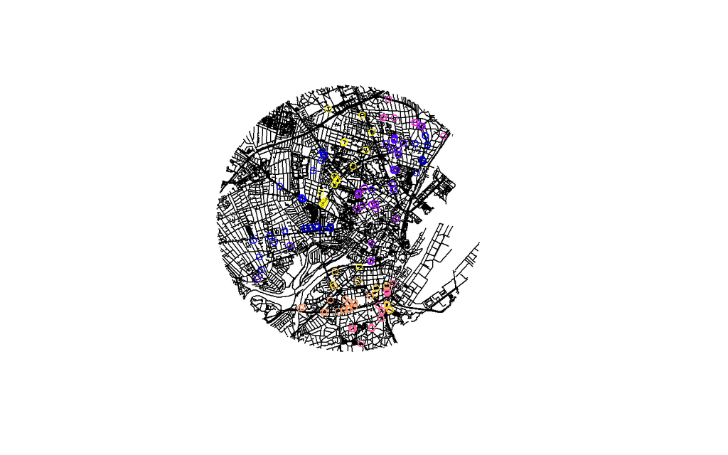

```r
plot(streets$geometry)
plot(BTG |>
    st_intersection(area), add = TRUE)
```

```r
times <- valid_network %>%
    sfnetworks::st_network_cost(venue, BTG |>
        st_intersection(area), weights = "time")

access <- BTG[which(times < units::set_units(6, "min")), ]

nrow(access)
```

```
[1] 5
```

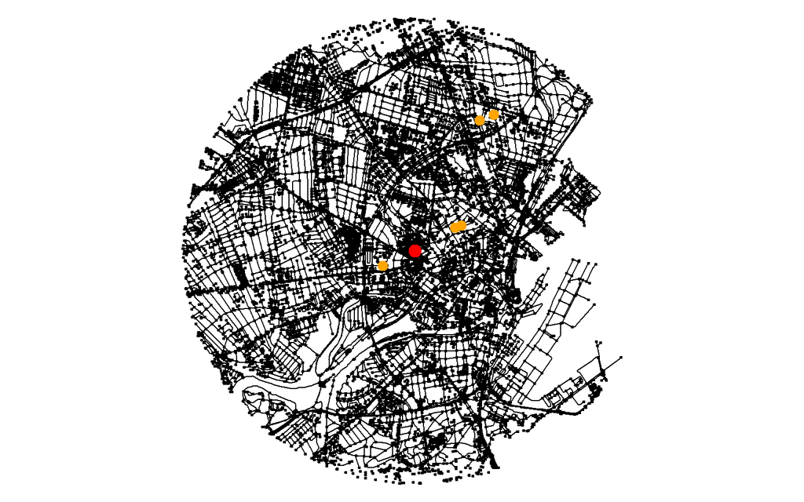

```r
par(mar = c(0, 0, 0, 0))
plot(valid_network, cex = 0.5)
plot(sf::st_geometry(access), col = "orange", pch = 20, cex = 2, add = TRUE)
plot(venue, col = "red", pch = 20, cex = 2.5, add = TRUE)
```

```r
suitable_network <- valid_network %>%
    tidygraph::activate("edges") %>%
    dplyr::filter(level %in% c("medium", "good"))

times <- suitable_network %>%
    sfnetworks::st_network_cost(venue, BTG %>%
        st_intersection(area), weights = "time")

access <- BTG[which(times < units::set_units(15, "min")), ]

nrow(access)
```

```
[1] 0
```

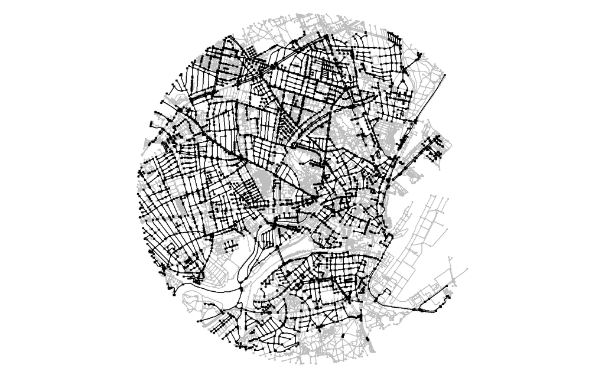

```r
trimmed_suitable_network <- suitable_network %>%
    tidygraph::activate("nodes") %>%
    dplyr::filter(!tidygraph::node_is_isolated())

par(mar = c(0, 0, 0, 0))
plot(network, col = "grey", cex = 0.4)
plot(trimmed_suitable_network, cex = 0.5, add = TRUE)
```

```r
plot(sf::st_geometry(access), col = "orange", pch = 20, add = TRUE)
```

And if we find only separated bike lanes to be acceptable, no sheltering for us!

```r
suitable_network <- valid_network %>%
    tidygraph::activate("edges") %>%
    dplyr::filter(level %in% c("good"))

times <- suitable_network %>%
    sfnetworks::st_network_cost(venue, BTG %>%
        st_intersection(area), weights = "time")

access <- BTG[which(times < units::set_units(15, "min")), ]

nrow(access)
```

```
[1] 0
```

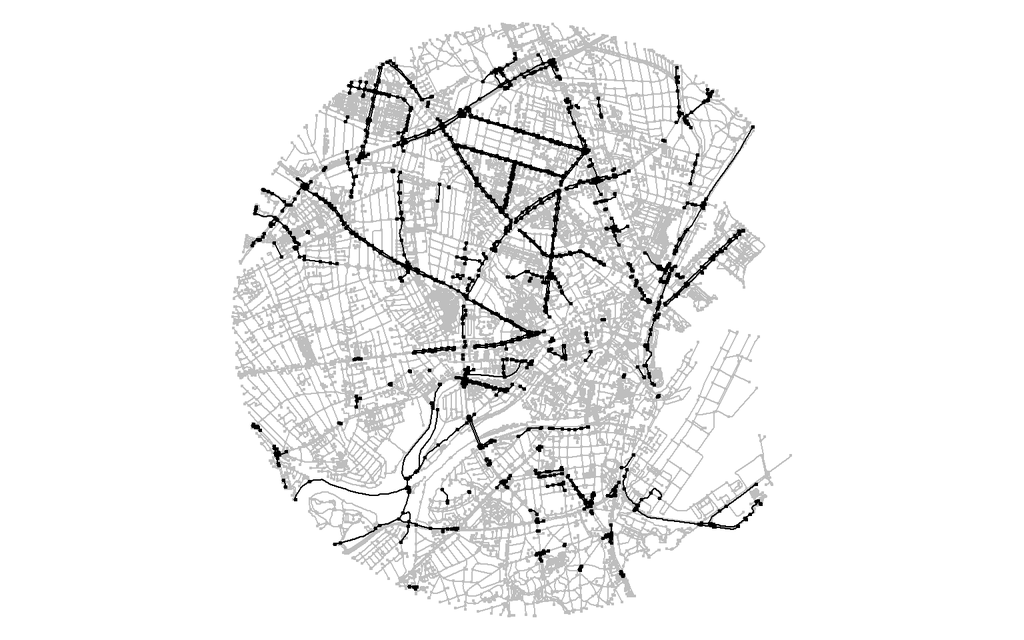

```r
trimmed_suitable_network <- suitable_network %>%
    tidygraph::activate("nodes") %>%
    dplyr::filter(!tidygraph::node_is_isolated())

par(mar = c(0, 0, 0, 0))
plot(network, col = "grey", cex = 0.4)
plot(trimmed_suitable_network, cex = 0.5, add = TRUE)
```

# Remarks

## 1. We simplified a lot

In this notebook we often used simple examples. In reality, accessibility of urban street networks is much more complex, with many factors at play.

## 2. We only touched upon the tip of the R iceberg

We showed a few R packages that are useful in the analysis of urban street networks. However, there are much more out there. The transport planning community in R is full of nice and talented people that share great work. Some examples:

- dodgr: A package for fast route calculations and flow aggregations on street networks based on C++ code.
- [cpprouting](https://github.com/vlarmet/cppRouting): A package for fast route calculations and traffic assignment on street networks based on C++ code.
- osrm: An R interface to the Open Source Routing Machine, a routing software for OpenStreetMap written in C++.
- [openrouteservice](https://github.com/GIScience/openrouteservice-r): An R interface to Openrouteservice, an open-source routing software written in Java.
- gtfsrouter: A package for fast route calculations on public transport time tables based on C++ code.
- r5r: An R interface to the R5 routing software for multi-modal routing.
- opentripplanner: An R interface to the OpenTripPlanner routing software for multi-modal routing.
- m4ra: A package for multi-modal routing based on C++ code (still in development).
- gtfsio: A package to read, represent and write General Transit Feed Specification data on public transport time tables.
- gtfstools: A package to edit and analyze General Transit Feed Specification data on public transport time tables.
- stplanr: A multi-purpose package for sustainable transport planning with functions for origin-destination matrix analysis, routing, and more.
- [accessibility](https://ipeagit.github.io/accessibility/): A package that implements different ways to compute transport accessibility metrics.

Read also the *Transportation* chapter of the open-source book [Geocomputation with R](https://r.geocompx.org/transport.html).

## 3. There is more to come

Open-source projects like sfnetworks are always in development. We are currently working on a new version of the package, hopefully to be released this fall. We are also working on a new package `bikesuiter` in which we are implementing different ways to analyze the bicycle suitability of street networks. Stay tuned!